# Christian Rivera Project 4 Udacity

Christian Rivera

May 16, 2016

# White Wine Dataset

## Introduction

For My Udacity Project 4 assignment, I chose to analyze the white wine dataset. This dataset consisted of 4898 samples with 12 values each. The analysis was meant to determine what, if any traits or traits determined the rated quality of a bottle of white wine. Using R, I extracted, cleaned and, tested with linear models, polinomial models, and decision trees. From my analysis, I concluded that, besides a moderate impact from how much alcohol the wine contains, that there is no correlation between the rated quality of a wine and its chemical characteristics.

## Data Analysis

Extracting the white wine data from a csv and running a summary on the data revealed the following statistics:

```
##  fixed.acidity    volatile.acidity  citric.acid     residual.sugar
##  Min.   : 3.800   Min.   :0.0800   Min.   :0.0000   Min.   : 0.600
##  1st Qu.: 6.300   1st Qu.:0.2100   1st Qu.:0.2700   1st Qu.: 1.700
##  Median : 6.800   Median :0.2600   Median :0.3200   Median : 5.200
##  Mean   : 6.855   Mean   :0.2782   Mean   :0.3342   Mean   : 6.391
##  3rd Qu.: 7.300   3rd Qu.:0.3200   3rd Qu.:0.3900   3rd Qu.: 9.900
##  Max.   :14.200   Max.   :1.1000   Max.   :1.6600   Max.   :65.800
##    chlorides       free.sulfur.dioxide total.sulfur.dioxide
##  Min.   :0.00900   Min.   :  2.00      Min.   :  9.0
##  1st Qu.:0.03600   1st Qu.: 23.00      1st Qu.:108.0
##  Median :0.04300   Median : 34.00      Median :134.0
##  Mean   :0.04577   Mean   : 35.31      Mean   :138.4
##  3rd Qu.:0.05000   3rd Qu.: 46.00      3rd Qu.:167.0
##  Max.   :0.34600   Max.   :289.00      Max.   :440.0
##     density             pH          sulphates         alcohol
##  Min.   :0.9871   Min.   :2.720   Min.   :0.2200   Min.   : 8.00
##  1st Qu.:0.9917   1st Qu.:3.090   1st Qu.:0.4100   1st Qu.: 9.50
##  Median :0.9937   Median :3.180   Median :0.4700   Median :10.40
##  Mean   :0.9940   Mean   :3.188   Mean   :0.4898   Mean   :10.51
##  3rd Qu.:0.9961   3rd Qu.:3.280   3rd Qu.:0.5500   3rd Qu.:11.40
##  Max.   :1.0390   Max.   :3.820   Max.   :1.0800   Max.   :14.20
##     quality
##  Min.   :3.000
##  1st Qu.:5.000
##  Median :6.000
##  Mean   :5.878
##  3rd Qu.:6.000
##  Max.   :9.000
```

As The R output shows, There are the wines in this list have 11 characteristics and a 0-10 quality score. The characteristics are as follows:

- 1. Fixed Acidity
- 2. Volatile Acidity
- 3. Citric Acid
- 4. Residual Sugar
- 5. Chlorides
- 6. Free Sulfur Dioxide
- 7. Total Sulfur Dioxide
- 8. Density
- 9. pH Level
- 10. Sulfates
- 11. Alcohol

Checking the distribution of quality scores revealed the following information:

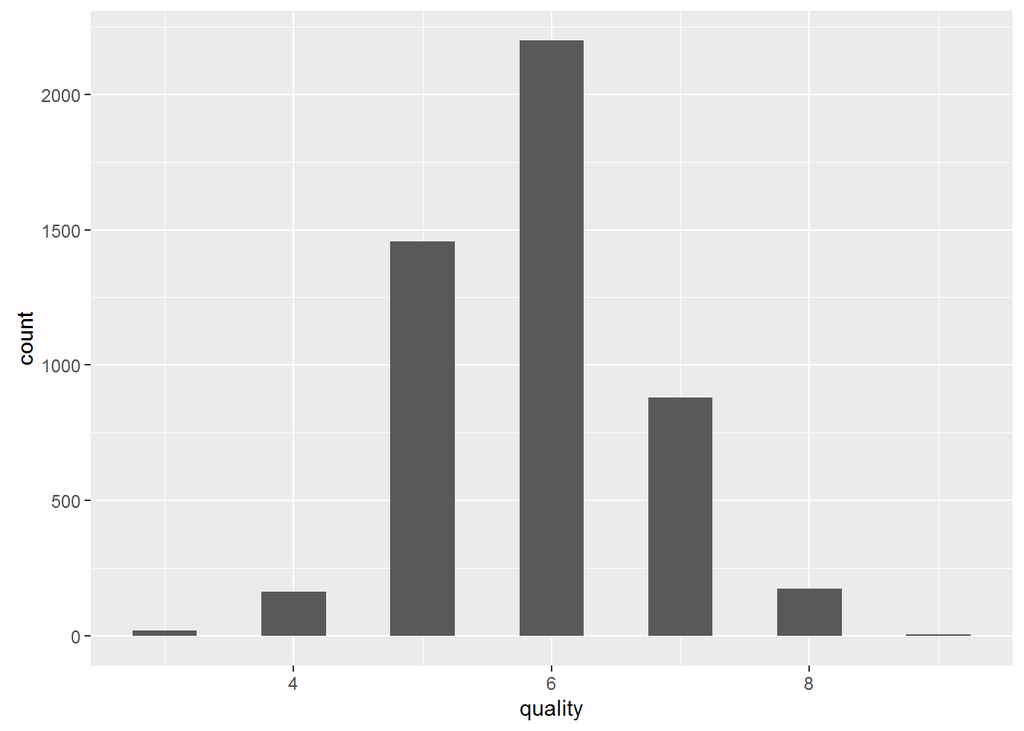

While this bargraph shows a normal distribution of the scoring of white wine, the extreme consolidation towards the average values (5,6,7); that no wines scored below a 3; that there are no perfect 10 wines; and that there are only 5 (0.1%) wines labled as 9’s suggests that there is no real consensus as what makes a good quality wine which is why the plurality of wines (44.7%) are 6’s and 92.4% of wines fall in the average range between 5-7.

The following bar graphs for the wine characteristics are shown below:

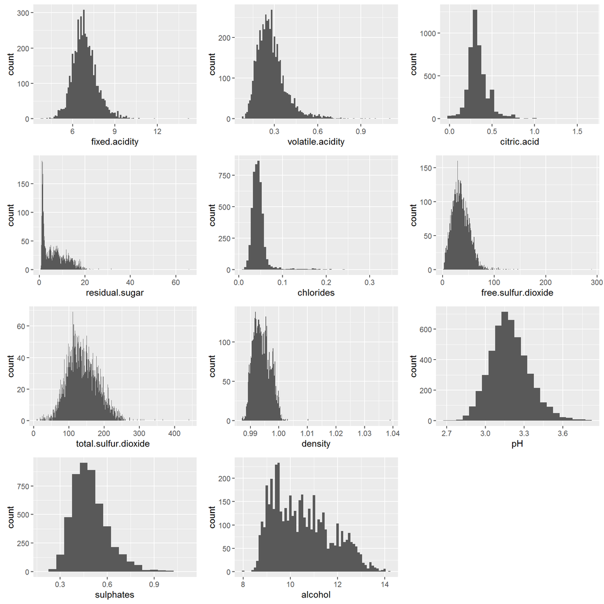

Most of the characteristics seems to have a normal distribution. These include: Fixed Acidity, Citric Acid, Chlorides, Free Sulfur Dioxide, Total Sulfur Dioxide, Density, and pH.

Sulphates and Volatile Acidity seem to have normal distributions with somewhat of a right skew.

Residual Sugar has an extreme right skew and alcohol has an even uniform distribution with a slight right skew.

The next step is to filter out the extremes for each characteristic which shrinks the sample wine size from 4898 to 3880. The filters and the new univariate bar graphs are shown below.

```r
# the filtered dataframe
wine1 <- wine
wine1 <-  filter(wine1, volatile.acidity <= 0.6 )
wine1 <- filter(wine1, citric.acid >= 0.2 & citric.acid <= 0.75)
wine1 <- filter(wine1, residual.sugar <= 20 & residual.sugar >= 0.3)
wine1 <- filter(wine1, chlorides <= 0.1)
wine1 <- filter(wine1, free.sulfur.dioxide <=100)
wine1 <- filter(wine1, total.sulfur.dioxide < 250 & total.sulfur.dioxide > 50)
wine1 <- filter(wine1, density >= 0.99 & density <=1.01)
wine1 <- filter(wine1, pH >= 2.85 & pH <= 3.6)
wine1 <- filter(wine1, sulphates >= 0.3 & sulphates <= 0.85)
wine1 <- filter(wine1, alcohol >= 8.5 & alcohol <= 13.5)

summary(wine1)
```

```
##  fixed.acidity    volatile.acidity  citric.acid     residual.sugar
##  Min.   : 4.800   Min.   :0.0800   Min.   :0.2000   Min.   : 0.60
##  1st Qu.: 6.400   1st Qu.:0.2100   1st Qu.:0.2800   1st Qu.: 1.90
##  Median : 6.900   Median :0.2500   Median :0.3200   Median : 6.20
##  Mean   : 6.953   Mean   :0.2652   Mean   :0.3477   Mean   : 6.84
##  3rd Qu.: 7.400   3rd Qu.:0.3100   3rd Qu.:0.4000   3rd Qu.:10.60
##  Max.   :14.200   Max.   :0.6000   Max.   :0.7400   Max.   :19.95
##    chlorides       free.sulfur.dioxide total.sulfur.dioxide
##  Min.   :0.01200   Min.   : 2.00       Min.   : 51.0
##  1st Qu.:0.03600   1st Qu.:24.00       1st Qu.:112.0
##  Median :0.04400   Median :34.00       Median :138.0
##  Mean   :0.04384   Mean   :35.63       Mean   :141.5
##  3rd Qu.:0.05000   3rd Qu.:46.00       3rd Qu.:169.2
##  Max.   :0.09900   Max.   :97.00       Max.   :249.5
##     density             pH          sulphates         alcohol
##  Min.   :0.9900   Min.   :2.850   Min.   :0.3000   Min.   : 8.50
##  1st Qu.:0.9920   1st Qu.:3.090   1st Qu.:0.4200   1st Qu.: 9.40
##  Median :0.9941   Median :3.180   Median :0.4800   Median :10.30
##  Mean   :0.9944   Mean   :3.185   Mean   :0.4932   Mean   :10.39
##  3rd Qu.:0.9965   3rd Qu.:3.280   3rd Qu.:0.5500   3rd Qu.:11.20
##  Max.   :1.0018   Max.   :3.600   Max.   :0.8500   Max.   :13.50
##     quality
##  Min.   :3.000
##  1st Qu.:5.000
##  Median :6.000
##  Mean   :5.891
##  3rd Qu.:6.000
##  Max.   :9.000
```

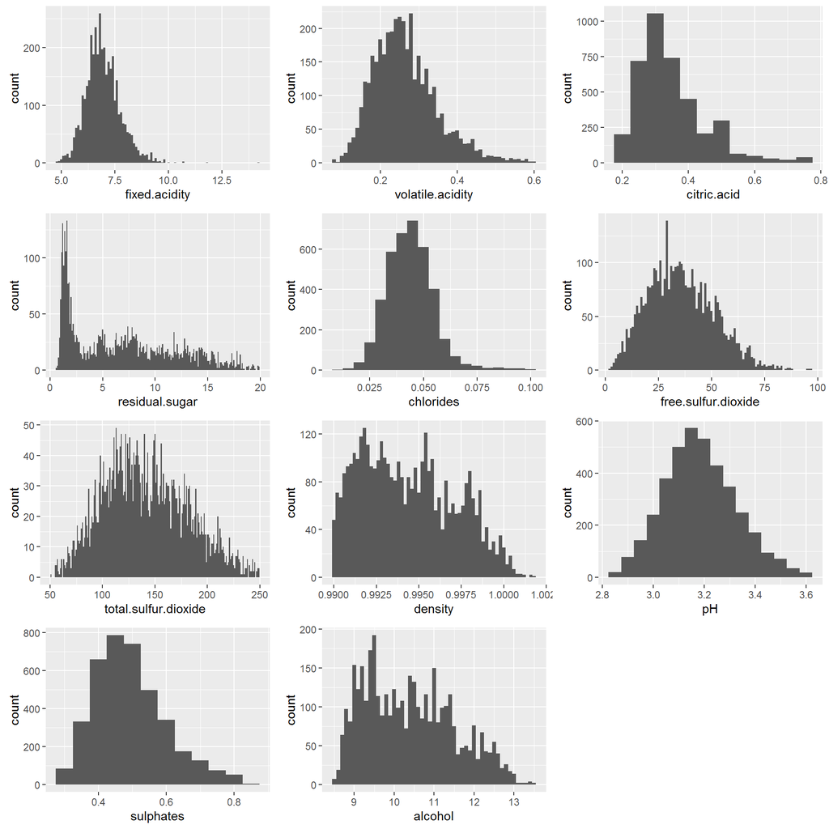

The filtered characteristics show new behaviors than before they were cleaned.

Of the characteristics that originally had normal distributions, only pH, Free Sulfur Dioxide, Chlorides, and Fixed Acidity remain.

Volatile Acidity, Citric Acid, sulphates, Alcohol, and Density have right skews and Residual Sugar keeps its extreme right skew although its skew has an even distribution.

Interestingly, Total Sulfur Dioxide has a mild bimodal distribution with peaks at 100 and 150 mg/l.

With the data cleaned of outliers, the values are compared against each other using the Pearson Product-Moment Correlation as well as graphed against each other in 2d scatterplots

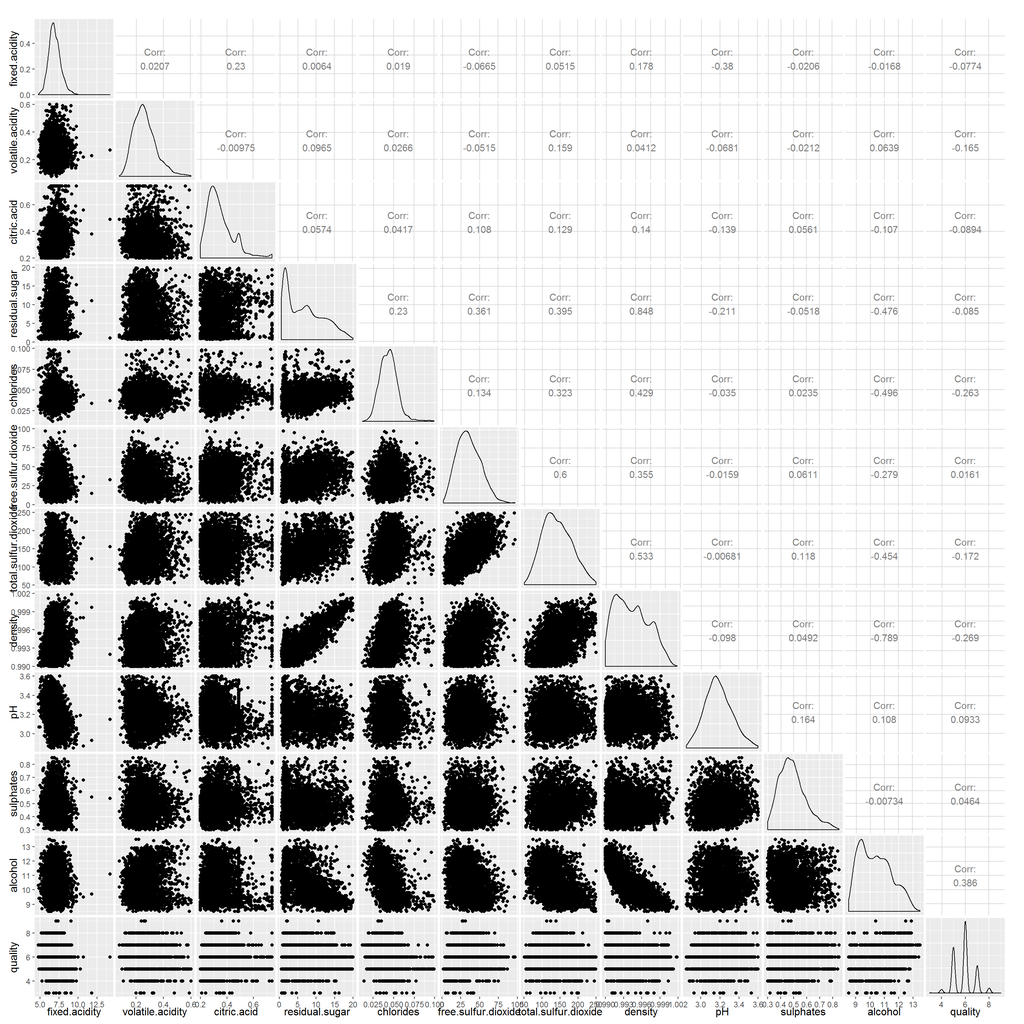

The r^2 correlation values are not promising with only alcohol scoring above a 0.3 (0.386) which suggests a mild correlation but certainly nothing definitive.

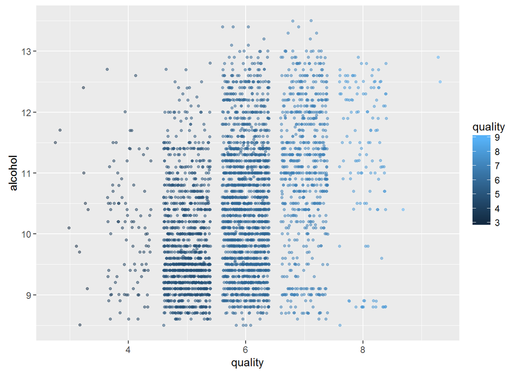

I used a jitter scatterplot graph to see if the combination of chlorides (-0.263 correlation to quality) and density (-0.269) as the 2nd and 3rd most correlating characteristics to wine quality would reveal a stronger correlation.

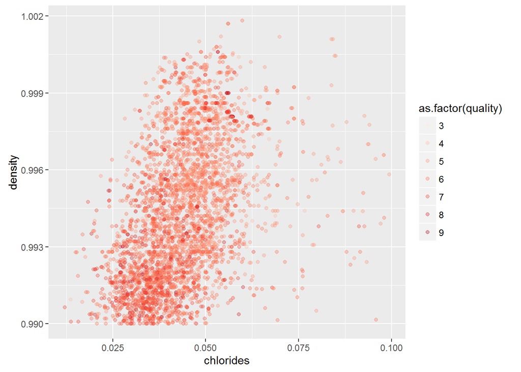

Unfrotunately this scatterplot graph shows a fairly even and random distribution of scores for the combination of chlorides and density to quality score so those attributes will provide minimal to no assistance in helping to find any correlation to quality score

Unfortunately, any attempts to transform the data does not meaningfully increase or decrease the correlation coefficients. Transforming the data on exponential (squares and squre roots) or logarithmic (log10) does very little to impact the correlation coefficients with changes in correlation accounting for +/- 0.02 changes in the coefficient scores. For example:

```r
with(wine1, cor.test(quality, (alcohol )))
```

```
##
##  Pearson's product-moment correlation
##
## data:  quality and (alcohol)
## t = 26.066, df = 3878, p-value < 2.2e-16
## alternative hypothesis: true correlation is not equal to 0
## 95 percent confidence interval:
##  0.3590023 0.4125622
## sample estimates:
##       cor
## 0.3861076
```

```r
with(wine1, cor.test(quality, log10(alcohol )))
```

```
##
##  Pearson's product-moment correlation
##
## data:  quality and log10(alcohol)
## t = 25.692, df = 3878, p-value < 2.2e-16
## alternative hypothesis: true correlation is not equal to 0
## 95 percent confidence interval:
##  0.3541724 0.4079601
## sample estimates:
##      cor
## 0.381389
```

```r
with(wine1, cor.test(quality, sqrt(alcohol )))
```

```
##
##  Pearson's product-moment correlation
##
## data:  quality and sqrt(alcohol)
## t = 25.892, df = 3878, p-value < 2.2e-16
## alternative hypothesis: true correlation is not equal to 0
## 95 percent confidence interval:
##  0.3567592 0.4104253
## sample estimates:
##       cor
## 0.3839164
```

```r
with(wine1, cor.test(quality, (alcohol)^2))
```

```
##
##  Pearson's product-moment correlation
##
## data:  quality and (alcohol)^2
## t = 26.33, df = 3878, p-value < 2.2e-16
## alternative hypothesis: true correlation is not equal to 0
## 95 percent confidence interval:
##  0.3624095 0.4158071
## sample estimates:
##       cor
## 0.3894355
```

## Linear and Polynomial Regression

With no avenues to transform the data for better correlation coefficients, the next step is to hope that a linear regression might be able to illuminate any relationship in the data. One of the linear regressions used included the following characteristics: alcohol, sulphates, pH value, free sulfur dioxide, and residual sugar. The results are shown below

```
##
## Calls:
## m1: lm(formula = I(quality) ~ I(alcohol), data = wine1)
## m2: lm(formula = I(quality) ~ I(alcohol) + sulphates, data = wine1)
## m3: lm(formula = I(quality) ~ I(alcohol) + sulphates + pH, data = wine1)
## m4: lm(formula = I(quality) ~ I(alcohol) + sulphates + pH + free.sulfur.dioxide,
##     data = wine1)
## m5: lm(formula = I(quality) ~ I(alcohol) + sulphates + pH + free.sulfur.dioxide +
##     residual.sugar, data = wine1)
##
## ==============================================================================
##                           m1         m2         m3         m4         m5
## ------------------------------------------------------------------------------
##   (Intercept)           2.812***   2.611***   1.815***   1.307***   0.522
##                        (0.119)    (0.133)    (0.296)    (0.299)    (0.322)
##   I(alcohol)            0.296***   0.297***   0.293***   0.321***   0.355***
##                        (0.011)    (0.011)    (0.011)    (0.012)    (0.013)
##   sulphates                        0.401***   0.340**    0.278*     0.318**
##                                   (0.121)    (0.122)    (0.121)    (0.121)
##   pH                                          0.272**    0.268**    0.375***
##                                              (0.090)    (0.089)    (0.090)
##   free.sulfur.dioxide                                    0.007***   0.006***
##                                                         (0.001)    (0.001)
##   residual.sugar                                                    0.019***
##                                                                    (0.003)
## ------------------------------------------------------------------------------
##   R-squared                 0.1        0.2        0.2        0.2        0.2
##   adj. R-squared            0.1        0.2        0.2        0.2        0.2
##   sigma                     0.8        0.8        0.8        0.8        0.8
##   F                       679.4      346.1      234.3      197.6      168.0
##   p                         0.0        0.0        0.0        0.0        0.0
##   Log-likelihood        -4563.1    -4557.6    -4553.1    -4516.2    -4495.6
##   Deviance               2387.1     2380.3     2374.8     2330.1     2305.5
##   AIC                    9132.2     9123.2     9116.1     9044.5     9005.3
##   BIC                    9151.0     9148.2     9147.4     9082.0     9049.1
##   N                      3880       3880       3880       3880       3880
## ==============================================================================
```

A correlation coefficient $r^{2}$ of 0.2 is would not be considered high enough to be a good fit and unfortunately none of the linear reression combinations I tried could beat beat it.

The next step was to try polynomial regression.One of the polynomial regressions I tried was a one where with alcohol, sulphates, and pH level:

```r
quadratic.model <- lm(quality ~ poly(alcohol, 2, raw=TRUE) +
                        poly(sulphates, 2, raw=TRUE) +
                        pH, data = wine1)

mtable(quadratic.model)
```

```
##
## Calls:
## quadratic.model: lm(formula = quality ~ poly(alcohol, 2, raw = TRUE) + poly(sulphates,
##     2, raw = TRUE) + pH, data = wine1)
##
## ==============================================
##   (Intercept)                       8.125***
##                                    (1.124)
##   poly(alcohol, 2, raw = TRUE)1    -0.894***
##                                    (0.213)
##   poly(alcohol, 2, raw = TRUE)2     0.056***
##                                    (0.010)
##   poly(sulphates, 2, raw = TRUE)1  -1.079
##                                    (0.923)
##   poly(sulphates, 2, raw = TRUE)2   1.346
##                                    (0.860)
##   pH                                0.364***
##                                    (0.091)
## ----------------------------------------------
##   R-squared                             0.2
##   adj. R-squared                        0.2
##   sigma                                 0.8
##   F                                   148.5
##   p                                     0.0
##   Log-likelihood                    -4536.1
##   Deviance                           2354.0
##   AIC                                9086.1
##   BIC                                9130.0
##   N                                  3880
## ==============================================
```

Once again, the results return a correlation coefficient ($r^{2}$) of 0.2.

## Decision Trees

Since regressions did not show any meaningful relationships between wine characteristics and quality score, the last analysis I attempted to discover a relationship was to apply a decision tree model to the data set. For this I used the install package ‘rpart’ and divide the dataset into 3 groups dependent on the quality score. All wines with scores lower than 6 were classified as ‘bad’, wines with a quality of 6 were classified as ‘average’ and wines with quality scores above six were classified as ‘good’

Using the following code, I applied a decision tree classification model with 6 variables (alcohol, sulphates, pH level, free sulfur dioxide, residual sugar, density:

```r
tree <-rpart(quality.class ~ alcohol +
               sulphates +
               pH +
               free.sulfur.dioxide +
               residual.sugar + density,
             data = wine1, method = "class")

printcp(tree)
```

```
##
## Classification tree:
## rpart(formula = quality.class ~ alcohol + sulphates + pH + free.sulfur.dioxide +
##     residual.sugar + density, data = wine1, method = "class")
##
## Variables actually used in tree construction:
## [1] alcohol             free.sulfur.dioxide residual.sugar
##
## Root node error: 2079/3880 = 0.53582
##
## n= 3880
##
##         CP nsplit rel error  xerror     xstd
## 1 0.036556      0   1.00000 1.00000 0.014942
## 2 0.021645      2   0.92689 0.98172 0.014960
## 3 0.020202      3   0.90524 0.96681 0.014971
## 4 0.018278      4   0.88504 0.91823 0.014979
## 5 0.011063      5   0.86676 0.88937 0.014964
## 6 0.010582      6   0.85570 0.90236 0.014973
## 7 0.010000      7   0.84512 0.90909 0.014976
```

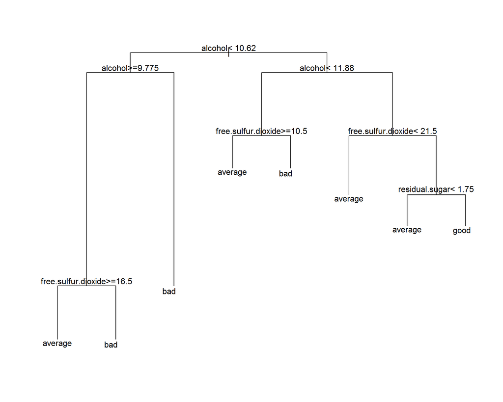

```r
plot(tree)
text(tree)
```

Still, as the decision tree branch above shows, the model only used 3 variables (alcohol, free sulfur dioxide, and residual sugar) and threw out the other 3 further supporting the idea that wine characteristics do not significantly impact the quality score of the wine.

# Conclusion

In conclusion, it appears that juding the quality of white wine is mostly a subjective matter and is not impacted a wine’s chemical characteristics. While a data set with a larger sample size and more documented characteristics might reveal stronger correlations between a white wine’s chemical properties and its quality score, the current dataset does not.

# Final Plots and Summary

### Scatterplot Graph

1. An improvement on the alcohol v. quality scatterplot. A linear regression, quadratic regreesion, and a locally weighted regression line have been applied. Jitter and alpha have been changed for the plot points. The points are color coded based on which quality class they are in and a title has been added. The regressions show the mild correlation between alcohol content and quality with their mostly postive diagonal slopes. These take into account that the ‘bad’ wines are mostly under 11% alcohol while the good wines are mostly over 10%. Still the near even distribution of ‘average’ wines reminds us that the correlation is still only mild.

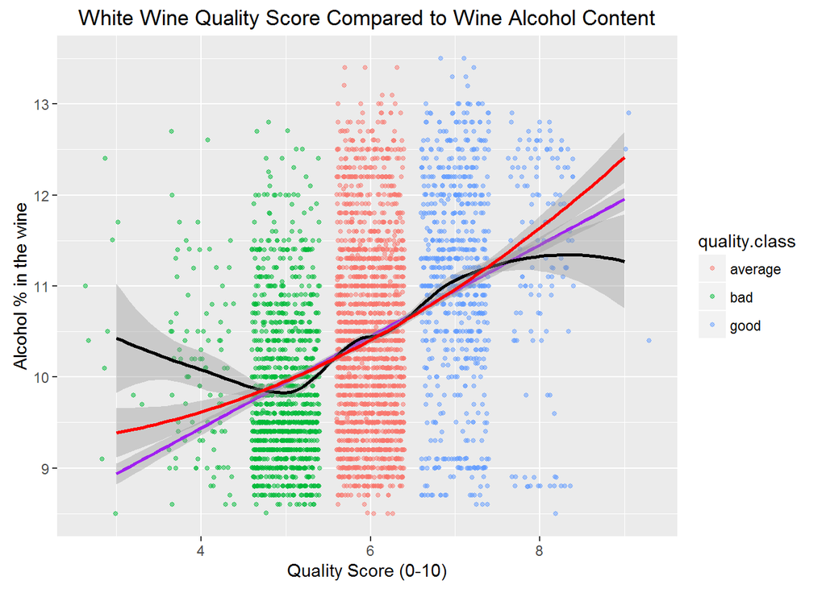

### Jitter Scatterplot Graph

2. An x-y graph with color coded points showing if a combination of chlorides and density values correlates to the wine quality score. The points have been assigned to the quality class rather than score and have been given distinct primary colors in order to tell the difference. As the graph shows, there seems to be more ‘good’ wines (green) with lower Density and Chloride values and more ‘bad’ (blue) wines with higher values however the even distribution of ‘average’ wines throughout the graph squash any idea that there is a strong or even moderate correlation between the intersection of Density/Chloride and a wine’s quality.

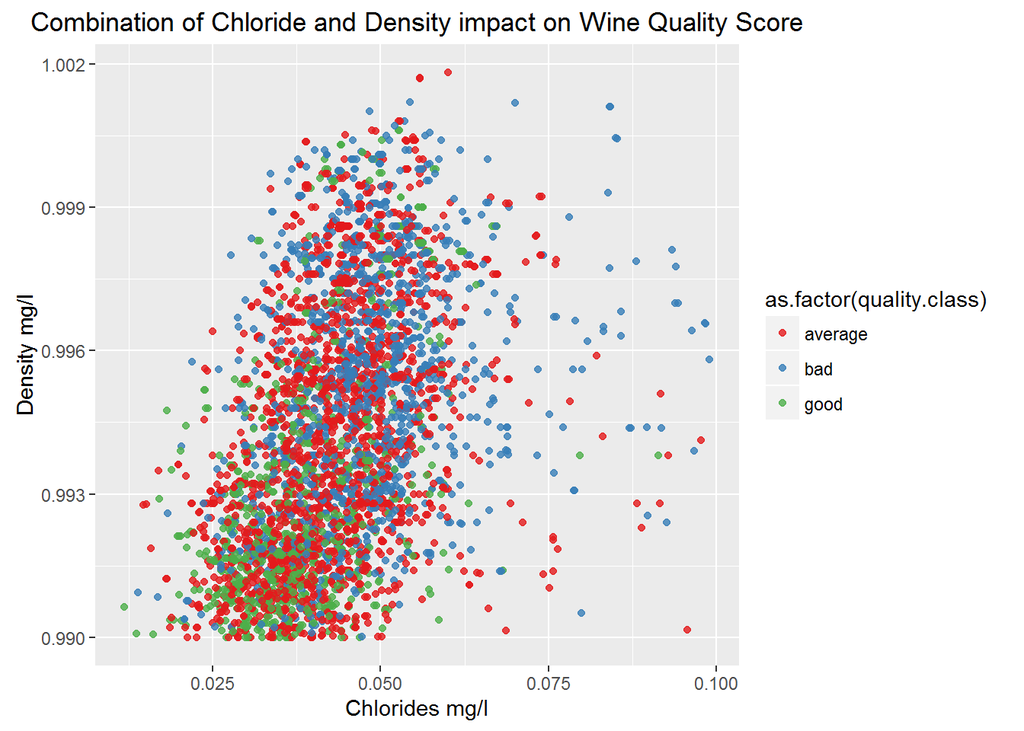

### Decision Tree

3. Searching the web for ways to create a better visualization of the decision tree, I settled on using the packages ‘rattle’ and ‘rpart.plot’ to create the superior decision tree shown below.

[figure not shown]

## Reflection

This data set proved frustrating as the desire to find some sort of meaning or objective relationship beween the characteristics of white wine and that wine’s quality score proved inconclusive or near non-existant everytime with none of the methods learned throughout the course providing definitive answers. Reaching out and using decision trees in this set was the only way for me to validate that the answers I was receiving from the regression models and correlating coefficients were accurate. As such, besides the decision tree results, I’m unsure if I can call any of it a success especially as there are were missing characteristics about the wines that could have been useful in the dataset. Such additions as where each wine was made and the types of grapes used I believe would greatly enhance the data. Also a larger sample set than 4800 would be beneficial.